# Chapter 5 - K - Nearest Neighbours

## K - Nearest Neighbours - Classfication

**KNN** is to classify a given observation to the class with highest estimated probability. Given a positive integer $K$ and a test observation $x_0$, the **KNN** classifier first identifies the K points in the training data that are closest to $x_0$, represented by $\mathcal{N}_0$. It then estimates the conditional probability for class $j$ as the fraction of points in $\mathcal{N}_0$ whose response values equal $j$:
$$\mathsf{P}(Y=j|X=x_0) = \frac{1}{K}\sum_{i \in \mathcal{N}_0}\mathbb{1}_{\{y_i = j\}}.$$
Finally, **KNN** applies Bayes rule and classifies the test observation $x_0$ to the class with the largest probability.

We will apply the **KNN** approach to the Caravan data set, which is part of the `ISLR` library. This data set includes 85 predictors that measure demographic characteristics for 5,822 individuals. The response variable is `Purchase`, which indicates whether or not a given individual purchases a caravan insurance policy. In this data set, only `6%` of people purchased caravan insurance.

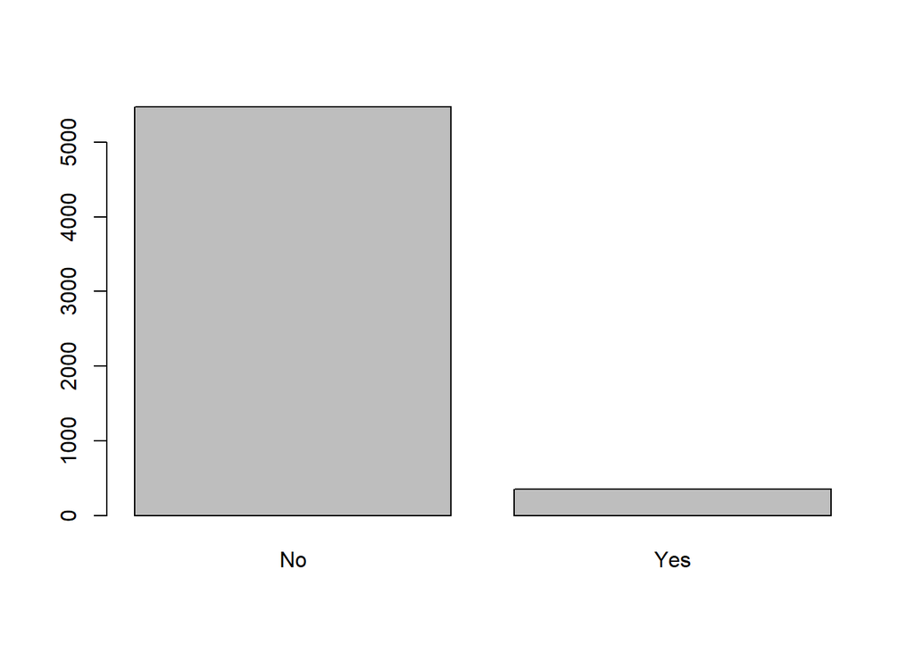

```r
library(ISLR)
caravan = na.omit(Caravan) # Read in data and delet the missing values
plot(caravan$Purchase)     # Proportion of the two classes
```

```r
table(caravan$Purchase)    # Count the
```

```
##
##   No  Yes
## 5474  348
```

For instance, imagine a data set that contains two variables, salary and age, measured in dollars and years, respectively. If we measure salary in Japanese yen, or if we measure age in minutes, then we’d get **quite different** classification results from what we get if these two variables are measured in dollars and years. A good way to handle this problem is to **standardize** the data so that all variables are given a mean of zero and a standard deviation of one. Then all variables will be on a comparable scale.

```r
y = caravan[,86]           # y - vecttor: Class Lable
x = scale(caravan[,-86])   # x - standardized table: Variables
n = nrow(caravan)          # No. of the observations
# test set
test = 1:2000
test_size = length(test)
```

Using K = 3 and 5:

```r
library(class)
# knn() - train and predict at the same time
knn_pred_3 = knn(train = x[-test,],  # train dataset
    test = x[test,],                 # test dataset
    cl = y[-test],                   # class label of the train
    k = 3)

knn_pred_5 = knn(train = x[-test,],
    test = x[test,],
    cl = y[-test],
    k = 5)

# talbe(x1, x2): build a x1-by-x2 contingency table
# "( xx = yyy )" will print out the "xx" in the console
(contTable3 = table(knn_pred_3, y[test]))
(contTable5 = table(knn_pred_5, y[test]))
contTable3[2, 2] / sum(contTable3[2, ])
contTable5[2, 2] / sum(contTable5[2, ])
```

```
##
## knn_pred_3   No  Yes
##        No  1849  114
##        Yes   30    7
##
## knn_pred_5   No  Yes
##        No  1863  117
##        Yes   16    4
## [1] 0.1891892
## [1] 0.2
```

When K = 3, the success rate increases to 7/37=18.92%, and with K = 5 the rate is 4/20=20%. This is much higher the rate that results from random guessing. It appears that KNN is finding some real patterns in a difficult data set.

As a comparison, we can also fit a logistic regression model to the data. If we instead predict a purchase any time the predicted probability of purchase exceeds 0.25:

```r
# library(ISLR)
# Try Logit-regression as a comparation:
dat = data.frame(y, x) # build a data frame using y and x
# glm() - general linear model
logit_fit = glm(formula = y ~., # formula: reg. y on all the rest
    family = "binomial", # Logit Regression
    data = dat, # the dataset we are using
    subset = -test) # subset: take only a part of the dataset,
                  #   the training part

# predict() using the estimated model to predict on new dataset
logit_prob = predict(logit_fit, # the estimated model
    newdata = dat[test,], # new dataset we want to predict on
    type = "response") # we get the predicted probability
# for those predicted prob. > 0.25, we set them to be "Yes",
#   O/W, let it to be "No"
logit_pred = rep("No", test_size)
logit_pred[logit_prob > 0.25] = "Yes"

(contTable = table(logit_pred, y[test]))
contTable[2,2]/sum(contTable[2,])
```

```
##
## logit_pred   No  Yes
##        No  1831  106
##        Yes   48   15
## [1] 0.2380952
```

We can get slightly better results: we predict that 63 people will purchase insurance, and we are correct for about 15/63=23.81% of these people.

## K - Nearest Neighbours - Regression

Linear regression is an example of a {parametric} approach because it assumes a linear functional form for $f(X)$. In contrast, **non-parametric** methods do not explicitly assume a parametric form for $f(X)$, and thereby provide an alternative and more flexible approach for performing regression. Here we consider one of the simplest and best-known non-parametric methods, K-nearest neighbours regression (KNN regression).

The **KNN regression** method is closely related to the **KNN classifier** discussed above. Given a value for K and a prediction point $x_0$, **KNN regression** first identifies the $K$ training observations that are closest to $x_0$, represented by $\mathcal{N}_0$. It then estimates $f(x_0)$ using the average of all the training responses in $\mathcal{N}_0$. In other words,
$$\hat{f}(x_0) = \frac{1}{K}\sum_{x_i \in \mathcal{N}_0}y_i.$$

We will apply the **KNN** approach to the Advertising data set, which we have met in the regression section. This data set includes 3 predictors that advertising expenses in TV, Radio and Newspapers for 200 records. The response variable is *Sales*, which indicates whether or not the three predictors are associated with sales.

The `knn.reg()` function in the package `FNN` is used to fitting a data by KNN. We split the advertising data half and half as test and training data respectively. To pick up the best $K$, we also need to apply cross validation.

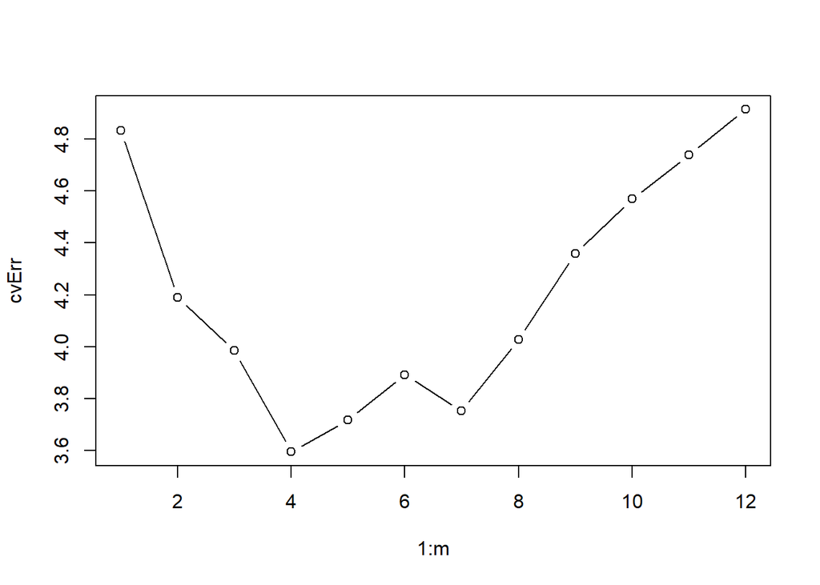

```r
# install.packages("FNN") - knn.reg()
library(FNN)
ad = read.csv(file = "Advertising.csv") # Read in data

y = ad$Sales        # y
x = scale(ad[,-5])  # x - regressors

n = nrow(ad)        # n - sample size
m = 12              # No. of different " 'K'NN " to try

# Prepare a vector to store the CV-Error
cvErr = rep(x = 0, times = m)
# test - vector: randomly sample ID's of the test dataset
set.seed(1234)
test = sample(1:n, size = 100, replace = F)

# Try those "K" in a for loop
for(i in 1:m){
    # knn.reg() - do a Leave-one-out CV
    knnReg = knn.reg(train = x[-test,],
        y = y[-test],
        k = i, # 'K'NN
        test = x[test,])

    # CV-Error
    cvErr[i] = mean((y[test] - knnReg$pred)^2)
}
plot(1:m, cvErr, type = "b")
```

```r
min(cvErr)
```

```
## [1] 3.595525
```

Try simple linear regreesion as a comparation:

```r
dat = data.frame(y, x)  # build a data frame using y and x
ls_fit = lm(formula = y~., data = dat, subset = -test)
# subset: take only a part of the dataset, the training part

# predict() using the estimated model to predict on new dataset
ls_pred = predict(ls_fit, newdata = dat[test,])
mean((y[test] - ls_pred)^2) # MSE: Mean-Square-of-Error
```

```
## [1] 2.572048
```

So, MSE of **KNN** is 3.60 while simple linear regressioin is just 2.57. So, why **KNN** regression performs even worse?

## Comparison

In what setting will a parametric approach such as least squares linear regression (logistic regression) outperform an non-parametric approach such as KNN regression (KNN classification)?

The answer is simple: **the parametric approach will outperform the non-parametric approach if the parametric form that has been selected is close to the true form of $f$** .

In the left plot, the blue dashed line is the least squares fit to the data. Since $f(X)$ is in fact linear (displayed as the black line), the least squares regression line provides a very good estimate of $f(X)$.

In the right plot, the dashed horizontal line represents the least squares test set MSE, while the green solid line corresponds to the MSE for KNN as a function of 1/K (on the log scale).

Linear regression achieves a lower test MSE than does KNN regression, since $f(X)$ is in fact linear. For KNN regression, the best results occur with a very large value of $K$, corresponding to a small value of $1/K$.

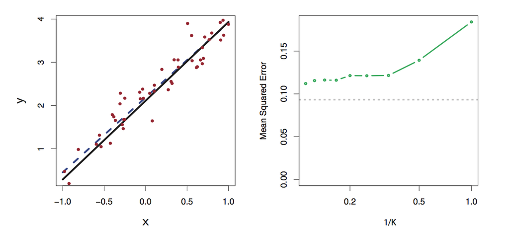

In the left plot, a setting with a slightly non-linear relationship between $X$ and $Y$ (solid black line), the KNN fits with $K = 1$ (blue) and $K = 9$ (red) are displayed.

In the right plot, for the slightly non-linear data, the test set MSE for least squares regression (horizontal black) and KNN with various values of 1/K (green) are displayed.

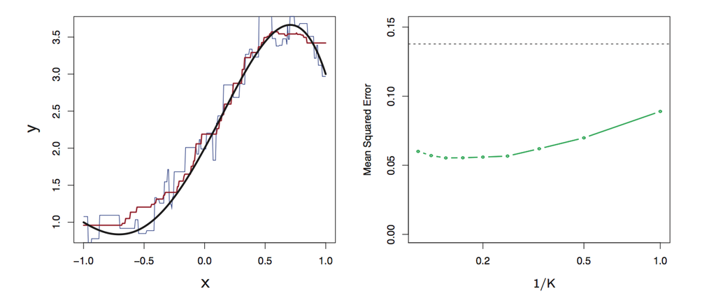

Test MSE for linear regression (black dashed lines) and KNN (green curves) as the number of variables $p$ increases. The true function is non-linear in the first variable, as in the plots in previous slides, and does not depend on the additional variables. The performance of linear regression deteriorates slowly in the presence of these additional noise variables, whereas KNN’s performance degrades much more quickly as $p$ increases.

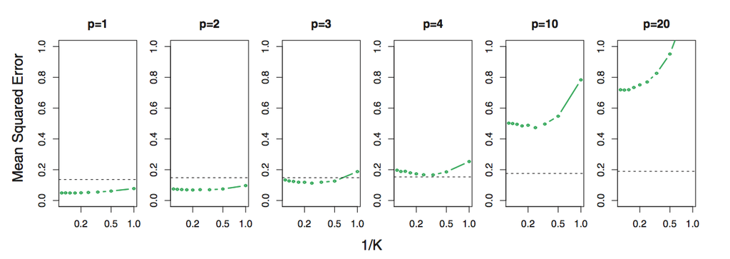

### Reference

James, Gareth, et al. An Introduction to Statistical Learning with Applications in R. Springer, 2017.